# Introduction to Data Science 11372 & 11516

Assignment 2 - Data Wrangling and Analysis

**Assignment Due:** 15th October 2023 - at 23:55

# Motivation

The purpose of this assignment is to assess your skills on reading data files into a single data frame, applying different cleaning and wrangling steps getting the data ready for the data modelling.

# Data Description

The observations in the attached CSV files have been taken from the Bureau of Meteorology’s “real time” system. These observations provide some details about the weather in the Australian Capital territory for **52 months**. Most of the data are generated automatically. Some quality checking has been performed, but it is still possible for erroneous values to appear. Sometimes, when the daily maximum and minimum temperatures, rainfall or evaporation are missing, the next value given has been accumulated over several days rather than the normal one day.

There are 52 comma-separated data files provided with this assignment. These data are for the months from **August 2018 to March 2023, (with some months were skipped)**. The variables reported in each file are described in Table 1.

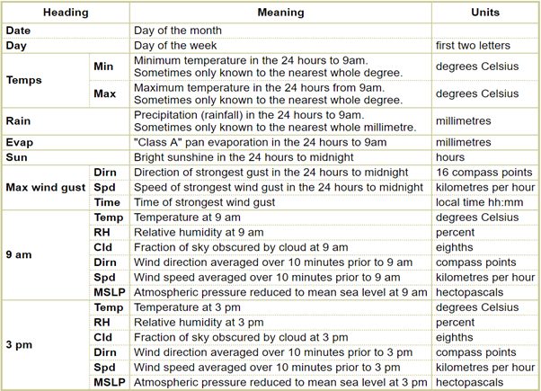

Table 1 - Column Meanings.

# Copyright of Data

Copyright of Bureau of Meteorology materials resides with the Commonwealth of Australia. Apart from any fair dealing for purposes of study, research, criticism and review, as permitted under copyright legislation, no part of this product may be reproduced, re-used or redistributed for any commercial purpose whatsoever, or distributed to a third party for such purpose, without written permission from the Director of Meteorology.

# Tasks

The following section includes tasks that must be attempted and reported on in your submission. You will provide *`.rmd`* files that include aspects of your formal reporting (*e.g.,* an introduction, assumptions) using **markdown** syntax, mixed with your R Code and results.

**Note:** The marking is based on two factors: 1) functionality of the code, and 2) overall presentation and documentation.

**Note** There are three parts for this assignment, where the required tasks for each part are listed in a separate `.rmd` file. You will need to download these `.rmd` files and write your answers inside them. Finally, you should submit files mentioned in the deliverable section below.

### Part A - Importing and Cleaning the data (15 Marks)

There are **52** CSV files in a compressed folder named `data.zip`, that needs to be downloaded and decompressed into your working directory. Then, tasks of part A need to be performed in `assignment2_partA.Rmd` file.

### Part B - Data Wrangling (33 Marks)

In this part, there are 10 questions mentioned in the file named `assignment2_partB.Rmd`. You will need to provide the answers in this file and knit it into an html and submit both of them.

### Part C - Insights (17 Marks)

# Deliverables

You are required to submit a compressed (e.g. ZIP) file to Canvas with the following files:

1. Three *`.rmd`* files with the markdown report & code for Tasks: Parts A, B and C,
2. Three HTML or PDF documents generated by *knitting* your *`.rmd`* files,
3. The `act_weather_data_partA.csv` file generated after performing tasks of part A.

Please follow the following structure to name the submitted zip file:

`[studentID_lastname_assignment2.zip]`

Replace the `studentID` with your university ID and `lastname` with your name.